# Exploration of 2016-2017 CITES Poaching Database

https://github.com/emilyrwood/CITES_Poaching_Wood

Emily Wood

```r
# wrangling Goal: cleaning the raw dataset into a format compatible

CITESPoaching2016$Reported_quantity <- CITESPoaching2016$Importer_reported_quantity +
    CITESPoaching2016$Exporter_reported_quantity

# Limit dataset to poaching occurrence measured by count not by weight.  I'm
# choosing count because the majority of cases are recorded in count not
# weight.  Select relevant columns

CITESPoaching2016["Unit"][is.na(CITESPoaching2016["Unit"])] <- "Count"

CITES2016_Processed <- CITESPoaching2016 %>%
    filter(Unit == "Count") %>%
    select(Year, Appendix, Class, Genus, Importer, Exporter, Importer_reported_quantity,
        Exporter_reported_quantity, Term, Purpose, Reported_quantity) %>%
    group_by(Appendix)

# Save the processed dataframe to processed folder
getwd()
```

```
## [1] "/home/guest/EDA_2022/CITES_Poaching_Wood"
```

```r
write.csv(CITES2016_Processed, row.names = FALSE, file = "./Data_Processed/CITES2016_Processed.csv")
```

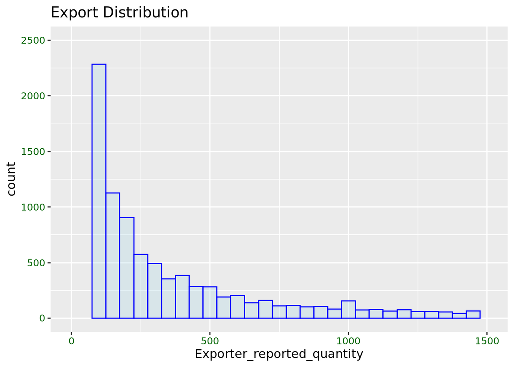

```r
Export.districution <- ggplot(CITESPoaching2016, aes(x = Exporter_reported_quantity)) +
    geom_histogram(binwidth = 50, colour = "blue", fill = "light blue", alpha = 0.3) +
    xlim(0, 1500) + ylim(0, 2500) + labs(title = "Export Distribution")
print(Export.districution)
```

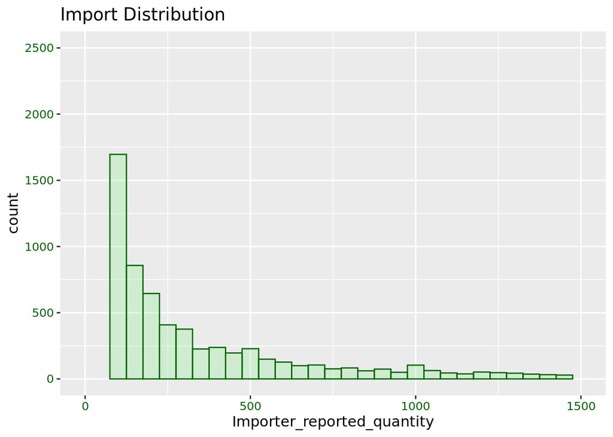

```r
Import.distribution <- ggplot(CITESPoaching2016, aes(x = Importer_reported_quantity)) +
    geom_histogram(binwidth = 50, colour = "dark green", fill = "light green", alpha = 0.3) +
    xlim(0, 1500) + ylim(0, 2500) + labs(title = "Import Distribution")
print(Import.distribution)
```

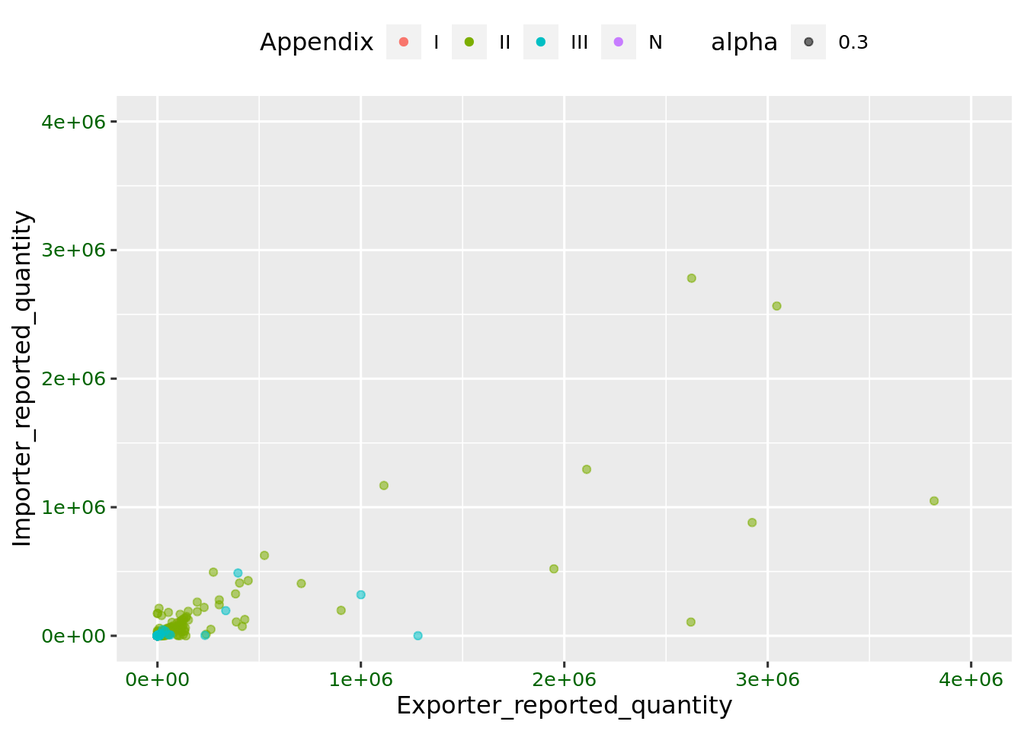

```r
Graphnew <- ggplot(CITESPoaching2016, aes(x = Exporter_reported_quantity, y = Importer_reported_quantity,
    color = Appendix, alpha = 0.3)) + geom_point() + xlim(0, 4e+06) + ylim(0, 4e+06)

print(Graphnew)
```

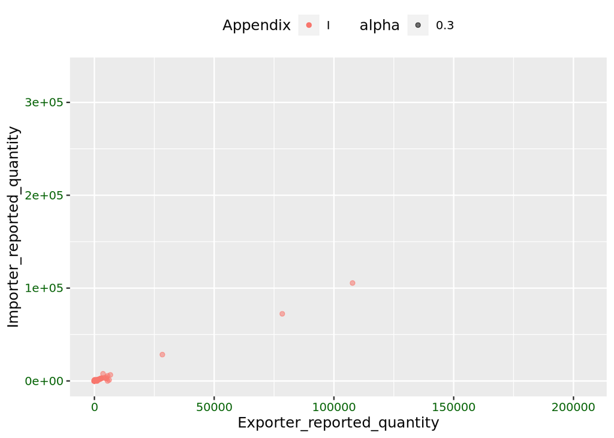

```r
Appendix1 <- ggplot(subset(CITESPoaching2016, Appendix == "I"), aes(x = Exporter_reported_quantity,
    y = Importer_reported_quantity, color = Appendix, alpha = 0.3)) + geom_point()
print(Appendix1)
```

```r
# Remove Null Values and combine Export and Import amounts into a total
# reported quantity column. Previous graphs should not contain the zeros.

CITESPoaching2016["Importer_reported_quantity"][is.na(CITESPoaching2016["Importer_reported_quantity"])] <- 0

CITESPoaching2016["Exporter_reported_quantity"][is.na(CITESPoaching2016["Exporter_reported_quantity"])] <- 0


# Visualizing countries with greater number of exports and imports Found
# journal to visualize countries
# https://journal.r-project.org/archive/2011-1/RJournal_2011-1_South.pdf
# install.packages('rworldmap')
library(rworldmap)

# Importer Countries
CITES_Importer_withmap <- joinCountryData2Map(CITES2016_Processed, joinCode = "ISO_A2",
    nameJoinColumn = "Importer")
```

```
## 59647 codes from your data successfully matched countries in the map
## 1112 codes from your data failed to match with a country code in the map
## 41 codes from the map weren't represented in your data
```

```r
mapDevice()  #create world map shaped window
mapCountryData(CITES_Importer_withmap, nameColumnToPlot = "Importer")
```

[output not shown]

```
## using catMethod='categorical' for non numeric data in mapCountryData
```

```r
Importerplot1 <- ggplot(CITES2016_Processed, aes(x = Importer)) + geom_bar(binwidth = 50,
    colour = "blue", fill = "light blue", alpha = 0.3)
print(Importerplot1)

# Difficult to interpret. Wrangle new dataset and create bar graph with only
# top 10 import countries:

table(CITES2016_Processed$Importer)
```

[output not shown]

```
##
##   AD   AE   AF   AG   AI   AL   AM   AN   AO   AR   AT   AU   AW   AZ   BA   BB
##   29 1295   94   14    1   95  103   12   60  286  498  490   99  168  145  116
##   BD   BE   BF   BG   BH   BJ   BL   BM   BN   BO   BQ   BR   BS   BW   BY   BZ
##  153  390    1   94  378    2   58   12   83    4   42  381   48    4  297    3
##   CA   CC   CD   CF   CG   CH   CI   CL   CM   CN   CO   CR   CU   CV   CW   CY
## 1230    4   21    1   17 2226   42  299    8 1779   74  108    7    7  107   87
##   CZ   DE   DJ   DK   DM   DO   DZ   EC   EE   EG   ER   ES   ET   FI   FJ   FO
##  409 4652    1  446    1   92   69   16   20  134    3  693   11   53    5   24
##   FR   GA   GB   GD   GE   GF   GG   GH   GI   GL   GM   GN   GP   GQ   GR   GT
## 2350    4 1121    4  145   60   17   51   45    9    1    2  127    2  138  197
##   GU   GY   HK   HN   HR   HT   HU   ID   IE   IL   IM   IN   IQ   IR   IS   IT
##   23    2 2249    8    9    5  124  337   88  362    6  317  202  252   29 1136
##   JE   JM   JO   JP   KE   KG   KH   KN   KP   KR   KW   KY   KZ   LA   LB   LC
##   29    9  220 4797   36   68   35   13  111 1206  671   21  376   30  385    5
##   LI   LK   LR   LT   LU   LV   LY   MA   MC   MD   ME   MF   MG   MK   ML   MM
##   10   22    2   48   12   29   25  176  172  159   92   18   93  142    3   28
##   MN   MO   MP   MQ   MR   MT   MU   MV   MW   MX   MY   MZ   NC   NE   NG   NI
##   18  265    8  114    2    4   86   97    8  608  622   12    9    4   87   11
##   NL   NO   NP   NZ   OM   PA   PE   PF   PG   PH   PK   PL   PR   PT   PW   PY
##  675  884   68  489  332  117  117    5    3  378  260  251    9  148    6   22
##   QA   RE   RO   RS   RU   RW   SA   SC   SD   SE   SG   SI   SK   SM   SN   SR
##  781  147   84  141  861    3  407    1   14  213 1364   24   68  122   87   99
##   SU   SV   SX   SY   SZ   TC   TD   TF   TG   TH   TJ   TK   TL   TM   TN   TR
##    7   22   64    4    7    1    2    2    5  812   26    2    2   63   98  938
##   TT   TW   TZ   UA   UG   US   UY   UZ   VC   VE   VG   VI   VN   WS   XV   XX
##   61 1066   13  483   19 8678   23  163    2   28   14    2  231    1   39  499
##   YE   YT   YU   ZA   ZM   ZW
##    2    1    5  523    8   74
```

```r
ImporterData <- CITES2016_Processed %>%
    group_by(Importer) %>%
    summarise(Importer, count = n()) %>%
    filter(Importer == "US" | Importer == "JP" | Importer == "DE" | Importer == "FR" |
        Importer == "HK" | Importer == "CH" | Importer == "CN" | Importer == "SG" |
        Importer == "AE" | Importer == "CA")
```

```r
Importerplot2 <- ggplot(ImporterData, aes(x = Importer)) + geom_bar(binwidth = 50,
    colour = "purple", fill = "lavender", alpha = 0.3)
print(Importerplot2)

# Exporter Countries
CITES_Exporter_withmap <- joinCountryData2Map(CITES2016_Processed, joinCode = "ISO_A2",
    nameJoinColumn = "Exporter")
```

[output not shown]

```
## 60130 codes from your data successfully matched countries in the map
## 629 codes from your data failed to match with a country code in the map
## 44 codes from the map weren't represented in your data
```

```r
mapDevice()  #create world map shaped window
mapCountryData(CITES_Exporter_withmap, nameColumnToPlot = "Exporter")
```

[output not shown]

```
## using catMethod='categorical' for non numeric data in mapCountryData
```

```r
Exporterplot1 <- ggplot(CITES2016_Processed, aes(x = Exporter)) + geom_bar(binwidth = 50,
    colour = "blue", fill = "light blue", alpha = 0.3)
print(Exporterplot1)

# Difficult to interpret. Wrangle new dataset and create bar graph with only
# top 10 export countries:

table(CITES2016_Processed$Exporter)
```

[output not shown]

```
##
##   AD   AE   AG   AL   AM   AO   AQ   AR   AT   AU   AW   AZ   BB   BD   BE   BG
##    2  838    8    5   27   10    2  302  305 1391    2   10   35    2 1153   15
##   BH   BI   BJ   BL   BM   BO   BR   BS   BW   BY   BZ   CA   CD   CF   CG   CH
##   52    1   24    4   35   16  463   42    3   30   15 1040   46    9   17 1339
##   CI   CK   CL   CM   CN   CO   CR   CU   CV   CW   CY   CZ   DD   DE   DK   DM
##   22   15   46   35 1133  497   52   86    1   27    1  751    1 1859  313    7
##   DO   EC   EE   EG   ER   ES   ET   FI   FJ   FK   FM   FO   FR   GA   GB   GD
##  109 1500   35    8    2 1056   73   35  501    9   52    1 2720   11 1038    5
##   GE   GG   GH   GI   GL   GM   GN   GP   GQ   GR   GS   GT   GW   GY   HK   HN
##   19   18   57    2  109    1    4    1   11   84    2   21    7  314  730    6
##   HR   HT   HU   ID   IE   IL   IM   IN   IO   IQ   IR   IS   IT   JE   JM   JO
##   16   10   49 6449   33   36    1  345   10    4    3   15 4776   82   69   14
##   JP   KE   KG   KH   KI   KM   KN   KR   KW   KY   KZ   LA   LB   LC   LI   LK
##  838  114   26   35    2    2   12  273  283   17   77  142   40    4    2   87
##   LR   LS   LT   LU   LV   MA   MC   MG   MH   MK   ML   MM   MN   MO   MT   MU
##   11    1   24   64   39   38  421  867   56   28   60   16   51   52   37   39
##   MV   MW   MX   MY   MZ   NC   NE   NG   NI   NL   NO   NP   NZ   OM   PA   PE
##    6   15  378 1258   80    2    1   15   60 7156   97    7   97  115  113 1226
##   PF   PG   PH   PK   PL   PT   PW   PY   QA   RO   RS   RU   RW   SA   SB   SC
##    8   22 1150   37   35  179   64   12  172   27   66  194    5   35   95   29
##   SD   SE   SG   SH   SI   SK   SL   SM   SN   SR   ST   SV   SX   SY   SZ   TC
##   37  101 1315    5   45   35    1   19   28  117    6   65    8   10    1    9
##   TD   TG   TH   TJ   TK   TL   TN   TO   TR   TT   TW   TZ   UA   UG   US   UY
##    3   65 1371   15    1    1   36  275  218   14  618  164   93   56 3879   49
##   UZ   VC   VE   VG   VN   VU   XV   XX   YE   ZA   ZM   ZW   ZZ
##  110    1   74   15  189    4    3   61    5 1369  128  524    6
```

```r
ExporterData <- CITES2016_Processed %>%
    group_by(Exporter) %>%
    summarise(Exporter, count = n()) %>%
    filter(Exporter == "NL" | Exporter == "ID" | Exporter == "IT" | Exporter == "US" |
        Exporter == "FR" | Exporter == "DE" | Exporter == "EC" | Exporter == "AU" |
        Exporter == "TH" | Exporter == "ZA")
```

```r
Exporterplot2 <- ggplot(ExporterData, aes(x = Exporter)) + geom_bar(binwidth = 50,
    colour = "blue", fill = "light blue", alpha = 0.3)
print(Exporterplot2)

# Which Classes get poached most often?

Classplot1 <- ggplot(CITES2016_Processed, aes(x = Class)) + geom_bar(aes(fill = Class)) +
    labs(title = "Classes of poaching occurances 2016", x = "Class", y = "Count") +
    theme(legend.position = "none") + coord_flip()

print(Classplot1)


# This has a lot of NAs perhaps they didn't record always the Class Faceted by
# appendix

Classplot2 <- ggplot(CITES2016_Processed, aes(x = Class)) + geom_bar(aes(fill = Class)) +
    labs(title = "Classes of poaching occurances 2016", x = "Class", y = "Count") +
    coord_flip() + facet_grid(rows = "Appendix") + theme(axis.text = element_text(size = 5))
print(Classplot2)

# create a facet dataset for Appendix I

AppendixI_Facet <- CITES2016_Processed %>%
    filter(Appendix == "I")


# A closer look at Mammalia

Mammalia_terms <- ggplot(subset(AppendixI_Facet, Class %in% "Mammalia"), aes(x = Term)) +
    geom_bar(aes(fill = Term)) + coord_flip() + theme(axis.text = element_text(size = 5),
    legend.key.size = unit(0.2, "cm"), legend.key.height = unit(0.2, "cm"), legend.key.width = unit(0.2,
        "cm"), legend.title = element_text(size = 3), legend.text = element_text(size = 3))

print(Mammalia_terms)

# A closer look at Aves

Aves_terms <- ggplot(subset(AppendixI_Facet, Class %in% "Aves"), aes(x = Term)) +
    geom_bar(aes(fill = Term)) + coord_flip() + theme(axis.text = element_text(size = 5),
    legend.key.size = unit(0.2, "cm"), legend.key.height = unit(0.2, "cm"), legend.key.width = unit(0.2,
        "cm"), legend.title = element_text(size = 3), legend.text = element_text(size = 3))

print(Aves_terms)

# A closer look at Reptilia

Reptilia_terms <- ggplot(subset(AppendixI_Facet, Class %in% "Reptilia"), aes(x = Term)) +
    geom_bar(aes(fill = Term)) + coord_flip() + theme(axis.text = element_text(size = 5),
    legend.key.size = unit(0.2, "cm"), legend.key.height = unit(0.2, "cm"), legend.key.width = unit(0.2,
        "cm"), legend.title = element_text(size = 3), legend.text = element_text(size = 3))

print(Reptilia_terms)

# Why arent plants represented in Class? monocotyledons or dicotyledons not
# depicted so potentiall in NAs

AppendixI_Facet["Class"][is.na(AppendixI_Facet["Class"])] <- "Not_recorded"

NA_terms <- ggplot(subset(AppendixI_Facet, Class %in% "Not_recorded"), aes(x = Term)) +
    geom_bar(aes(fill = Term)) + coord_flip() + theme(axis.text = element_text(size = 5),
    legend.key.size = unit(0.2, "cm"), legend.key.height = unit(0.2, "cm"), legend.key.width = unit(0.2,
        "cm"), legend.title = element_text(size = 3), legend.text = element_text(size = 3))

print(NA_terms)
```

[output not shown]

# Rationale and Research Questions

Poaching remains a considerable threat to biodiversity across the planet. However, it often is overshadowed by other environmental issues in the policy realm. This is especially true for species that aren’t charismatic mega-fauna. I’m undertaking this research project to better understand the trends in poaching over time and understand the regions where the most risk is occuring. This could help target poaching hotspots and help policy makers make more informed decisions when it comes to mitigating poaching risk for sesitive species.

Main Questions:

Is there any correlation between class, term, appendix number and poaching amount?

Sub Questions:

What is the distribetion of amounts found exported and imported for all species included in the database?

Are there differences between Appendix Levels for the amount exported vs. imported?

What are the most commonly poached classes between Appendix Levels?

What are the top 3 Classes for species poached in Appendix I?

What are the dominant good types (terms) for the top 3 classes poached in Appendix I?

Which Counties are the biggest Importer and Exporters of CITES species?

```r
# Two way ANOVA

# Linear modeling

# 1.How Does Reported Poaching Quantity vary over Class and Term for only
# Appendix 1.

Poaching.2way <- aov(data = AppendixI_Facet, Reported_quantity ~ Class + Term)
summary(Poaching.2way)
```

```
##              Df    Sum Sq   Mean Sq F value   Pr(>F)
## Class         6 4.467e+09 744583316   9.911 1.37e-10 ***
## Term         26 3.259e+09 125332949   1.668   0.0198 *
## Residuals   853 6.408e+10  75125682
## ---
## Signif. codes:  0 '***' 0.001 '**' 0.01 '*' 0.05 '.' 0.1 ' ' 1
## 4768 observations deleted due to missingness
```

```r
# P-value is small. Reject our null hypothesis that the mean across our groups
# is different.  Not enough information to tell us which groups are differing

Poaching.2way2lm <- lm(data = AppendixI_Facet, Reported_quantity ~ Class + Term)
summary(Poaching.2way2lm)
```

```
##
## Call:
## lm(formula = Reported_quantity ~ Class + Term, data = AppendixI_Facet)
##
## Residuals:
##    Min     1Q Median     3Q    Max
## -11288    -54    -40    -11 201942
##
## Coefficients:
##                                Estimate Std. Error t value Pr(>|t|)
## (Intercept)                   1.128e+04  6.391e+03   1.764    0.078 .
## ClassAmphibia                -1.169e+04  9.028e+03  -1.295    0.196
## ClassAves                    -1.123e+04  1.542e+03  -7.282 7.46e-13 ***
## ClassCoelacanthi             -1.124e+04  9.390e+03  -1.197    0.232
## ClassMammalia                -1.127e+04  1.812e+03  -6.220 7.76e-10 ***
## ClassNot_recorded            -1.123e+04  1.521e+03  -7.386 3.59e-13 ***
## ClassReptilia                -1.087e+04  2.602e+03  -4.175 3.28e-05 ***
## Termbodies                   -3.633e+01  7.032e+03  -0.005    0.996
## Termbones                     2.100e+01  1.062e+04   0.002    0.998
## Termcarvings                 -2.632e+02  6.612e+03  -0.040    0.968
## Termcloth                     2.000e+00  1.062e+04   0.000    1.000
## Termcosmetics                 5.633e+04  1.083e+04   5.204 2.45e-07 ***
## Termeggs                      7.105e+01  7.359e+03   0.010    0.992
## Termfeathers                 -3.855e+01  1.069e+04  -0.004    0.997
## Termfeet                     -2.000e+00  8.668e+03   0.000    1.000
## Termgarments                 -2.610e+02  7.397e+03  -0.035    0.972
## Termhair                      2.260e+02  1.062e+04   0.021    0.983
## Termhorn carvings            -2.000e+00  1.062e+04   0.000    1.000
## Termivory carvings            2.679e+01  6.248e+03   0.004    0.997
## Termivory pieces              1.570e-11  1.062e+04   0.000    1.000
## Termleather products (large) -4.078e+02  1.083e+04  -0.038    0.970
## Termleather products (small) -3.057e+02  6.644e+03  -0.046    0.963
## Termlive                      1.360e+01  6.230e+03   0.002    0.998
## Termoil                       1.063e+04  1.083e+04   0.982    0.326
## Termpiano keys                2.540e+02  7.912e+03   0.032    0.974
## Termskin pieces               1.765e+03  1.083e+04   0.163    0.871
## Termskins                     3.111e+02  6.609e+03   0.047    0.962
## Termskulls                    5.000e+00  8.668e+03   0.001    1.000
## Termspecimens                 4.168e+02  6.420e+03   0.065    0.948
## Termteeth                     1.880e+02  8.668e+03   0.022    0.983
## Termtrophies                  8.776e+00  6.253e+03   0.001    0.999
## Termtusks                     1.830e+01  6.292e+03   0.003    0.998
## Termwood product             -1.015e+01  6.776e+03  -0.001    0.999
## ---
## Signif. codes:  0 '***' 0.001 '**' 0.01 '*' 0.05 '.' 0.1 ' ' 1
##
## Residual standard error: 8668 on 853 degrees of freedom
##   (4768 observations deleted due to missingness)
## Multiple R-squared:  0.1076, Adjusted R-squared:  0.07412
## F-statistic: 3.214 on 32 and 853 DF,  p-value: 9.76e-09
```

```r
# means are different. Reject null

TukeyHSD(Poaching.2way)
```

```
##   Tukey multiple comparisons of means
##     95% family-wise confidence level
##
## Fit: aov(formula = Reported_quantity ~ Class + Term, data = AppendixI_Facet)
##
## $Class
##                                   diff        lwr       upr     p adj
## Amphibia-Actinopteri     -1.128759e+04 -37247.303 14672.114 0.8588566
## Aves-Actinopteri         -1.123236e+04 -15772.442 -6692.282 0.0000000
## Coelacanthi-Actinopteri  -1.128759e+04 -37247.303 14672.114 0.8588566
## Mammalia-Actinopteri     -1.124305e+04 -15784.531 -6701.579 0.0000000
## Not_recorded-Actinopteri -1.123459e+04 -15717.307 -6751.882 0.0000000
## Reptilia-Actinopteri     -1.025311e+04 -15099.786 -5406.433 0.0000000
## Aves-Amphibia             5.523246e+01 -25616.737 25727.202 1.0000000
## Coelacanthi-Amphibia     -6.821210e-13 -36226.291 36226.291 1.0000000
## Mammalia-Amphibia         4.453965e+01 -25627.677 25716.756 1.0000000
## Not_recorded-Amphibia     5.300054e+01 -25608.886 25714.887 1.0000000
## Reptilia-Amphibia         1.034485e+03 -24693.476 26762.446 0.9999998
## Coelacanthi-Aves         -5.523246e+01 -25727.202 25616.737 1.0000000
## Mammalia-Aves            -1.069281e+01  -2412.478  2391.093 1.0000000
## Not_recorded-Aves        -2.231917e+00  -2290.961  2286.497 1.0000000
## Reptilia-Aves             9.792528e+02  -1959.087  3917.593 0.9572473
## Mammalia-Coelacanthi      4.453965e+01 -25627.677 25716.756 1.0000000
## Not_recorded-Coelacanthi  5.300054e+01 -25608.886 25714.887 1.0000000
## Reptilia-Coelacanthi      1.034485e+03 -24693.476 26762.446 0.9999998
## Not_recorded-Mammalia     8.460892e+00  -2283.036  2299.958 1.0000000
## Reptilia-Mammalia         9.899456e+02  -1950.551  3930.442 0.9551104
## Reptilia-Not_recorded     9.814847e+02  -1867.414  3830.384 0.9498794
##
## $Term
##                                                            diff         lwr
## bodies-baleen                                     -4.077150e+00  -25419.651
## bones-baleen                                       2.100000e+01  -39352.637
## carvings-baleen                                   -6.595024e+02  -24558.394
## cloth-baleen                                       2.000000e+00  -39371.637
## cosmetics-baleen                                   5.574605e+04   16372.417
## eggs-baleen                                        1.009072e+02  -26796.408
## feathers-baleen                                   -8.692809e+00  -39382.330
## feet-baleen                                       -2.000000e+00  -32150.440
## garments-baleen                                   -5.995785e+02  -27496.893
```

[output cut: 679 more lines]

```
## specimens-skulls                                   23605.6214 1.0000000
## teeth-skulls                                       32331.4401 1.0000000
## trophies-skulls                                    23195.4419 1.0000000
## tusks-skulls                                       23351.9805 1.0000000
## wood product-skulls                                24729.4234 1.0000000
## teeth-specimens                                    23533.1809 1.0000000
## trophies-specimens                                  7328.7749 1.0000000
## tusks-specimens                                     7783.9169 1.0000000
## wood product-specimens                             11220.6953 1.0000000
## trophies-teeth                                     23012.4419 1.0000000
## tusks-teeth                                        23168.9805 1.0000000
## wood product-teeth                                 24546.4234 1.0000000
## tusks-trophies                                      7011.3303 1.0000000
## wood product-trophies                              10739.0283 1.0000000
## wood product-tusks                                 11043.7858 1.0000000
```